# Racialization and Perceived Institutional Ideology

**Karla Magaña, Devin Judge-Lord**  
*University of Michigan*

`"Diversity has been removed from the FBI's list of organizational Core Values. Visual and informational materials promoting Diversity as a Core Value are being removed from FBI space." - FBI`

`The National Park Service display on George Washington’s ownership of enslaved people`

## Theory

### Historical Institutional Racialization

- Fights over racial exclusion/integration were central to the development of the federal bureaucracy

(King, 1999; Choi and Rainey, 2010; Schickler, 2016; Tate, 2003; White and Laird, 2020; Mansbridge, 1999; Watkins-Hayes, 2009; Minta, 2009; Juenke and Preuhs, 2012; Hayes and Hibbing, 2017)

### Race & Policy Framing

- Racial discourse shapes policy preferences and political behavior
- Language brings power into focus

(Gilens, 1999; Kellstedt, 2003; Hutchings & Valentino, 2004; Woodly, 2015; Bartels, 2020; Stephens-Dougan, L., 2020; McConnell-Ginet., 2020; Woodly, 2022; O’Brian, 2024)

### Race & Ideology

- Perceived liberal-conservative ideology affects politics

(Clinton and Lewis, 2008; Richardson et al., 2019; Richardson et al., 2024; Epstein, 1999; Nixon, 2004; Chen and Johnson, 2014; Bonica et al., 2015; Maranto, 2005; Maranto and Hult, 2004; Bertelli and Grose, 2011; Acs, 2025)

## Institutional Racialization

Racialization is the level to which the public and elite language used to describe an institution and its actions evoke race and thus make it relevant and highlight debates around racial inequality or racial resentments.

- A legacy of civil-rights era reforms? Evidence of compliance, resistance, or erosion?
- Affected by non-white agency leaders or employees?
- Affects responsive to racial justice claims?
- Affects the careers of bureaucrats?

## This Paper’s Research Questions

How consistent is racialization…

- in different contexts (e.g., the media, advocacy, and policymaking)?
- over time?
- with perceived conservative or liberal ideology?

## Data

- Mandate for Leadership (Project 2025)
  - 128 agencies, 7,545 sentences, 853 racialized
- New York Times
  - 22 agencies, 146,491 articles, 38,965 racialized
- Rulemaking Documents
  - 214 agencies, 102,146 rules, 19,684 racialized
- Perceived Agency Ideology (Richardson et al., 2019)

## Racialized Language

> Affirmative Action; African American; African Americans; Alaskan Native; Alien; American Indian; Anti-discrimination; Anti-racism; Anti-racist; Antidiscrimination; Antiracism; Antiracist; Arab American; Asian American; BIPOC; Biracial; Black American; Black Americans; Black children; Black lives; Black Man; Black Men; Black People; Black Person; Black Students; Black Woman; Black Women; Border Crisis; Civil Rights; Color of their skin; Communities of Color; Critical Race Theory; Cultural competence; Culturally competent; D.E.I.; DACA; DEI; Diversity and inclusion; Diversity Equity; Diversity lottery; Diversity objectives; Diversity officer; Diversity visa; Diversity, Equity; Diversity, Equity, and Inclusion; Drug Cartel; Enslavement; Equal Opportunity; Equity agenda; Ethnic; Ethnic Diversity; Ethnicity; Gang; HBCU; Hispanic; Historically Black College and University; Illegal Alien; Illegal aliens; Illegal Immigrant; Illegal immigrants; Illegal immigration; Illegal migration; Immigrant; Immigration; Indian Education; Indigenous groups; Indigenous people; Indigenous peoples; Indigenous person; Inequality; Inequitable; Intersectionality; Latina; Latinas; Latino; Latinos; Latinx; Men of Color; Meritocracy; Mexican Cartel; Mexican Drug Cartel; Middle Eastern or North African Ancestry; Migrant; Minority Populations; Minority status; Minority-Serving; Mixed race; Mixed-race; Multicultural; Multiracial; Muslim; Native American; Native-Serving; Non-white; Nonminority; Oppressors; Pacific Islander; People of Color; People of Minority Status; Person of Color; Predominately white; Prejudice; Puerto Ricans; Racial; Racial Diversity; Racial Identity; Racial Inequality; Racial Inequities; Racial Injustices; Racial Justice; Racially; Racism; Racist; Secure Border; Secure the Border; Securing the Border; Skin color; Slavery; Social Justice; Socioeconomic; Socioeconomically; South Asian American; South Asians; Stereotypes; Structural Racism; Systemic Racism; Unaccompanied Alien Children; Underrepresented Communities; Underrepresented Minorities; Underserved Communities; Underserved Populations; Vulnerable populations; White American; White Americans; White institutions; White People; White Person; White Privilege; White students; White supremacist; White supremacy; Woke; Wokeism; Women of Color; Xenophobia; Xenophobic

## New York Times Articles, 2005-2025

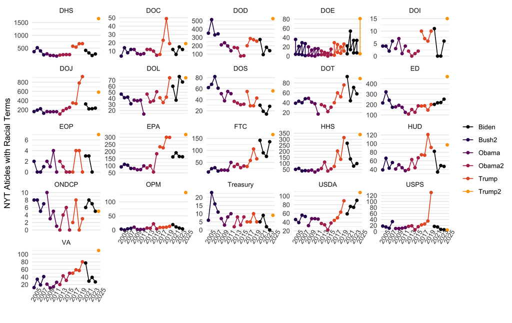

Figure 1: New York Times Articles With Racialized Words By Agency, 2005-2025

## New York Times Articles, 2005-2025

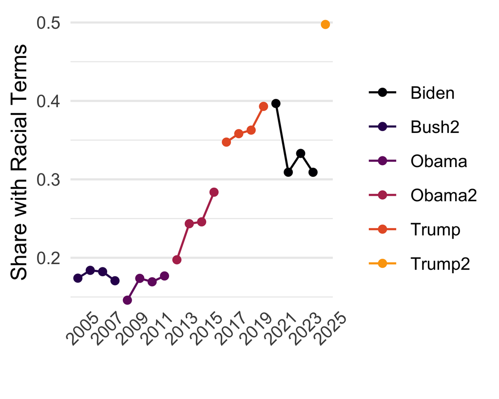

Figure 2: New York Times Articles With Racialized Words, 2005-2025

## Agency Rules, 2005-2025

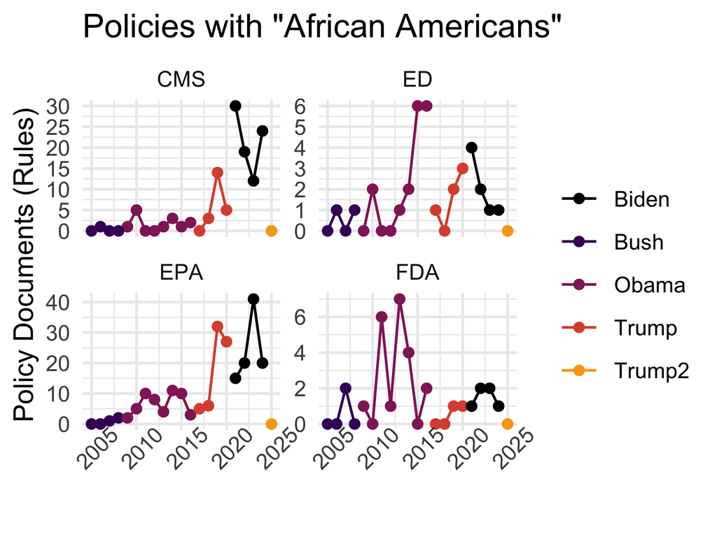

(a)

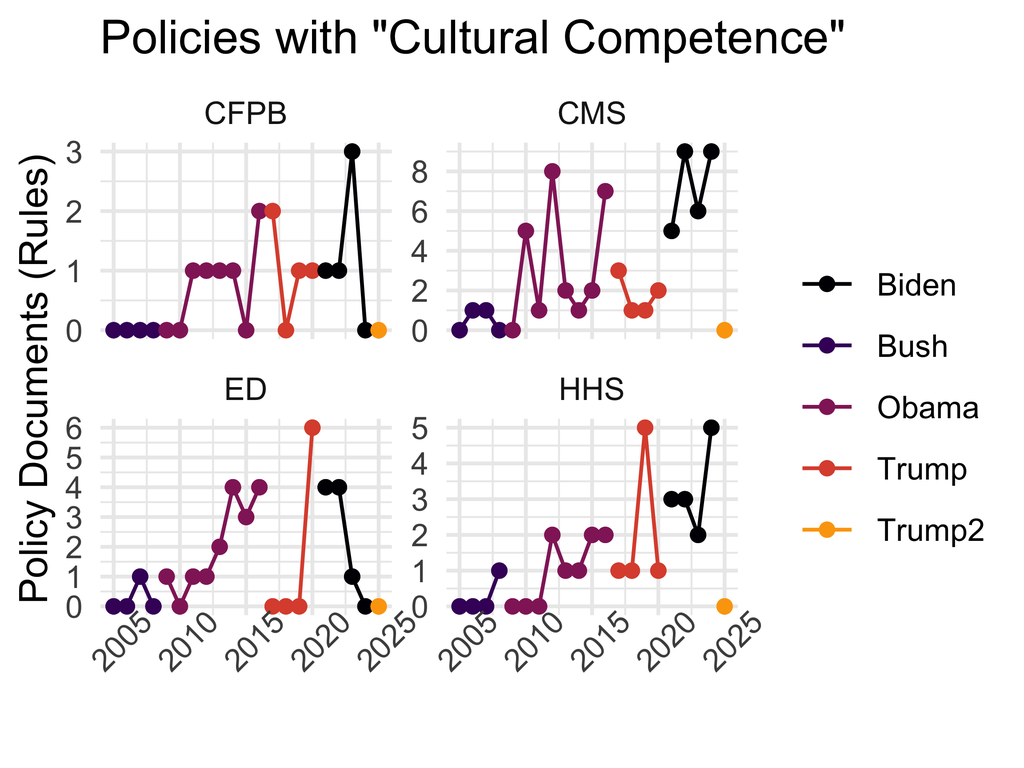

(b)

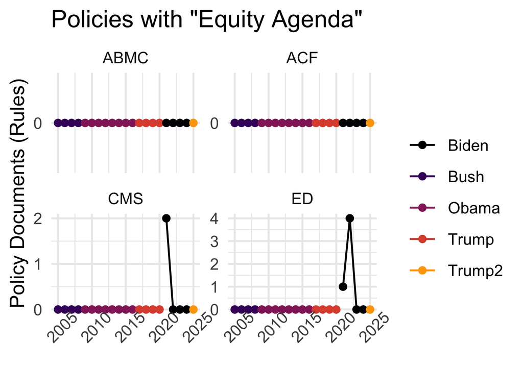

(c)

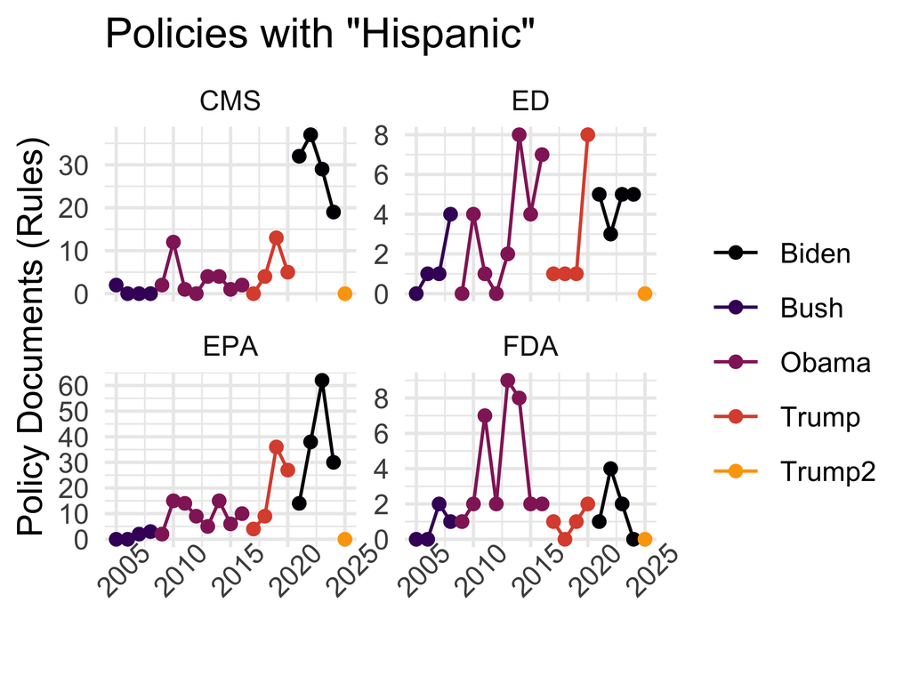

(d)

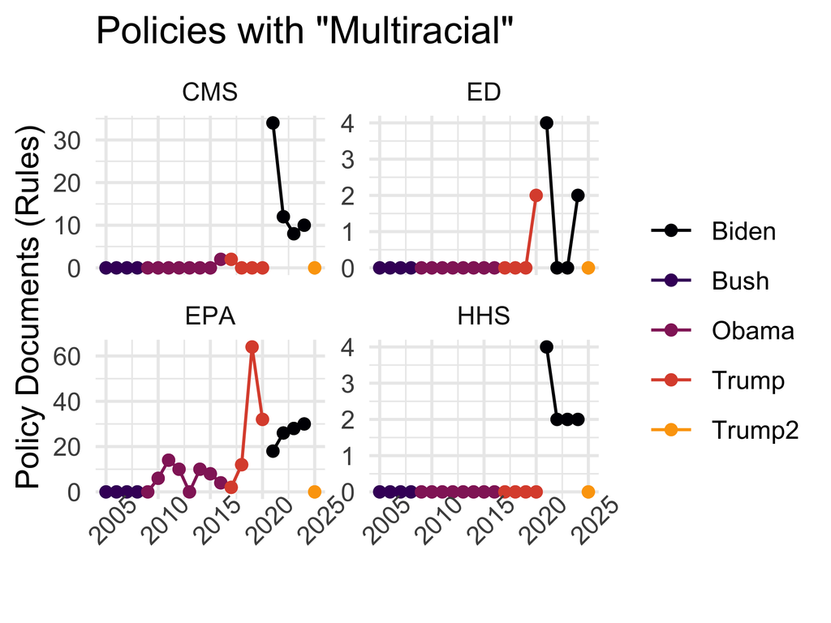

(e)

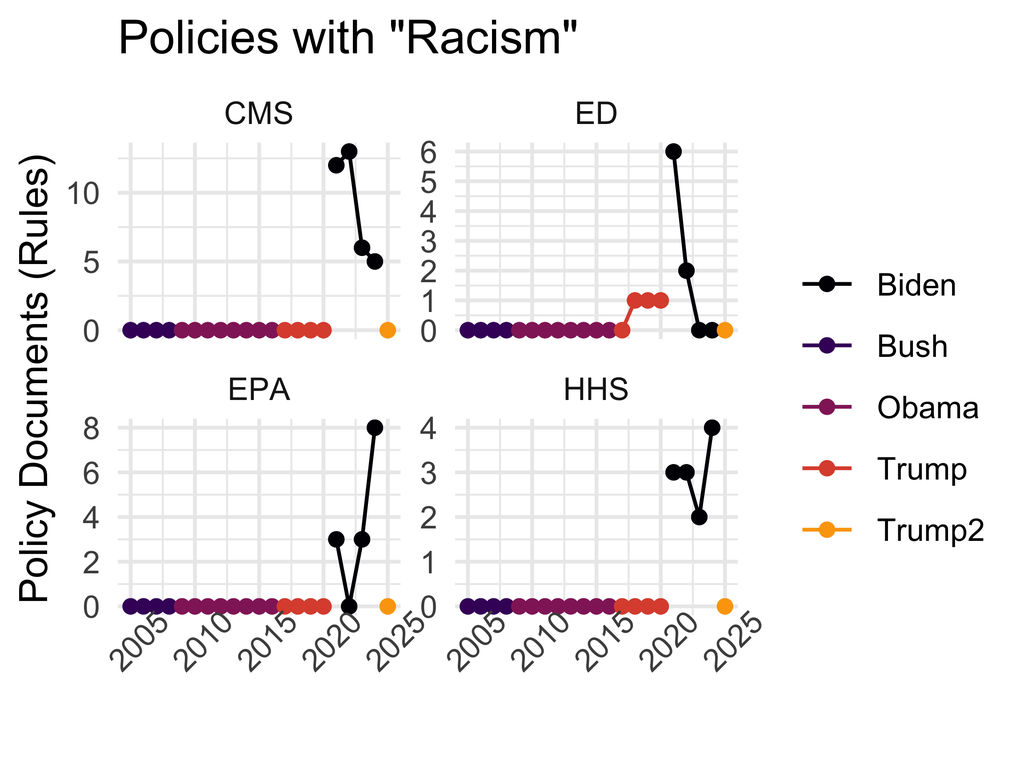

(f)

Figure 3: Agency Rules with Racialized Language, by Agency, 2005-2025

## Agency Rules, 2005-2025

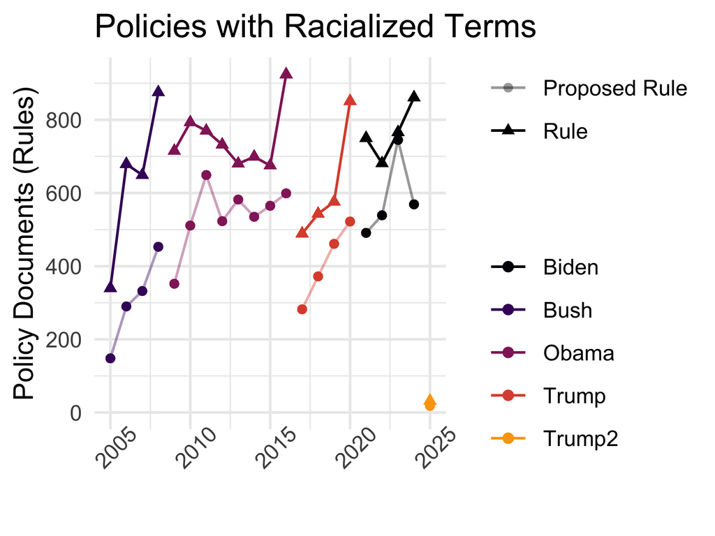

Figure 4: Agency Rules with Racialized Language, 2005-2025

## Project 2025 Mandate For Leadership Report

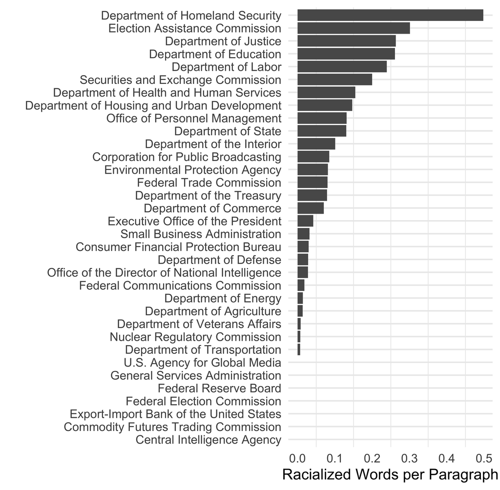

Figure 5: Racialized Words in Project 2025 Mandate For Leadership

# Comparing Aross Contexts

For each source, we count $r_{i}$ (**racialized** documents/articles/sentences about agency $i$) and $y_{i}$ (the **total** documents/articles/sentences about agency $i$).

Share Racialized $x_i = \frac{\sqrt{r_{i}}}{\sqrt{y_{i}}}$ (variance stabilized)

Racialization Score $z_{i} = \frac{x_i - \bar{x}}{sd(x)}$ (standardized, mean 0, standard deviation 1)

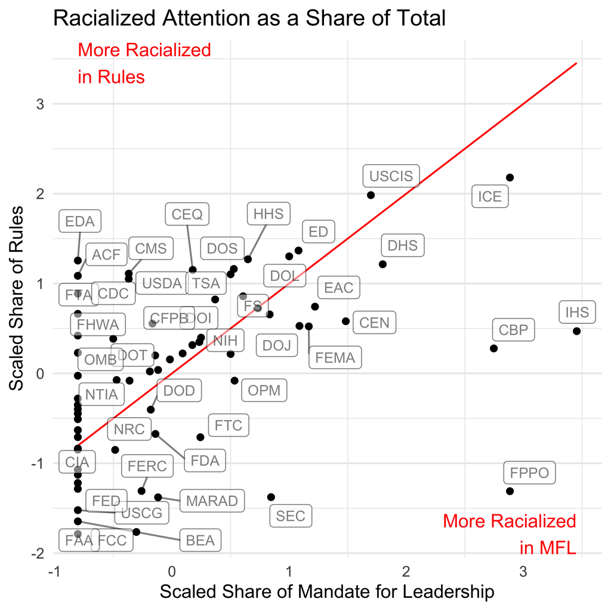

Figure 6: Racialization in Rulemaking vs. Project 2025

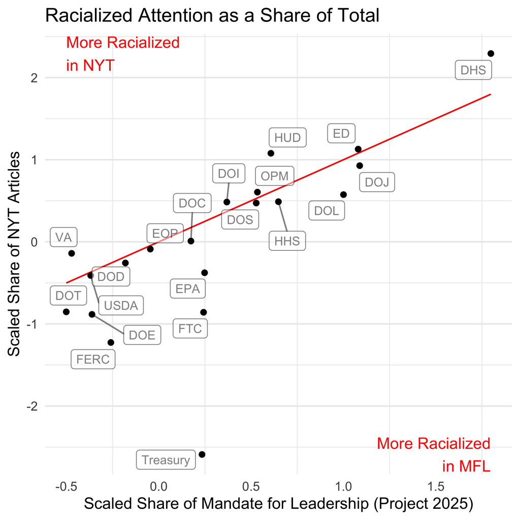

Figure 7: Racialization in Project 2025 vs. New York Times

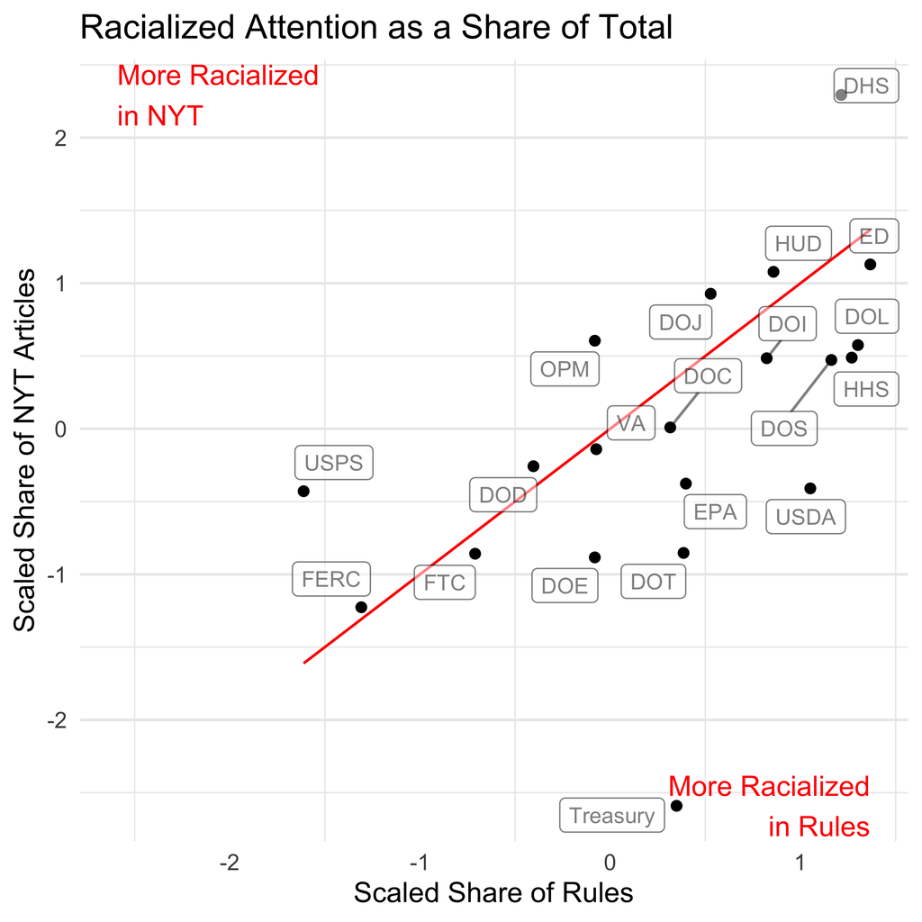

Figure 8: Racialization in Rulemaking vs. New York Times

# Comparing with ideology scores

## Racialization and Perceived Ideology

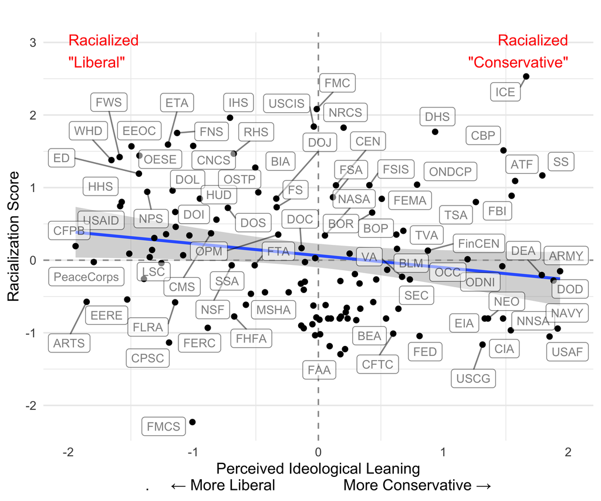

Figure 9: Racialization and Perceived Ideology

## Racialization and Perceived Centrism

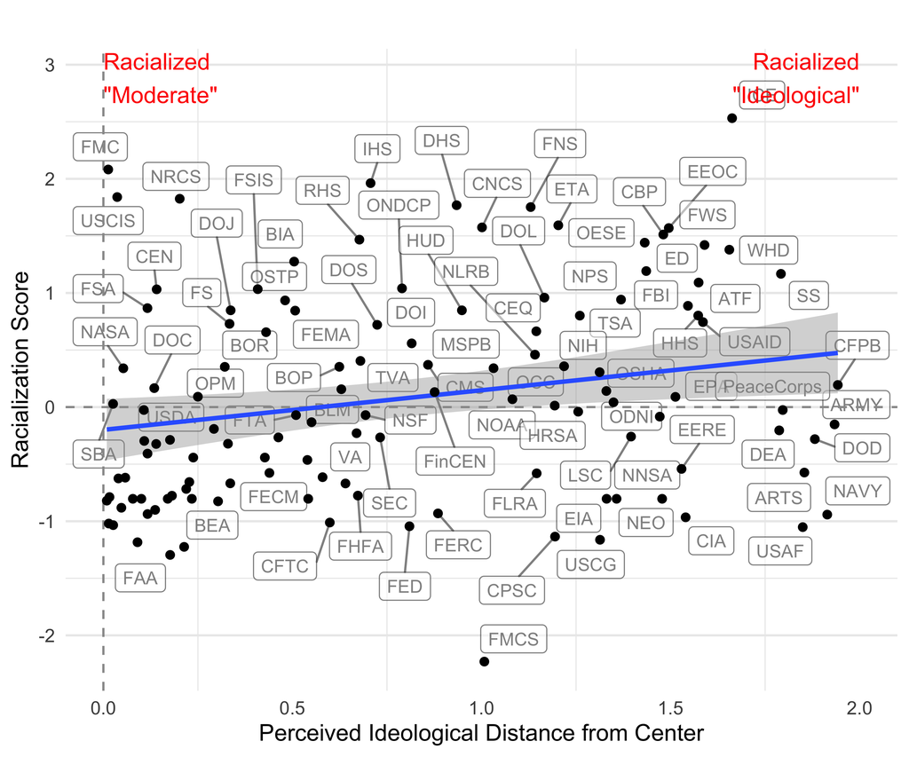

Figure 10: Racialization and Perceived Centrism

## To Conclude

- Racialization varies massively over time, despite stable core missions
- Racialized agencies are perceived as more ideological

**Next Steps**

- Time series data for advocacy reports $\rightarrow$ Dynamic scores
- Compare with other agency ideology/partisanship measures (e.g., Chen Johnson 2015, Acs 2025, etc.)
- Examine the effects of leadership’s race on discourse
- Examine the effects on bureaucratic responsiveness

**Comments:** kmagana@umich.edu | judgelor@umich.edu

# Extra

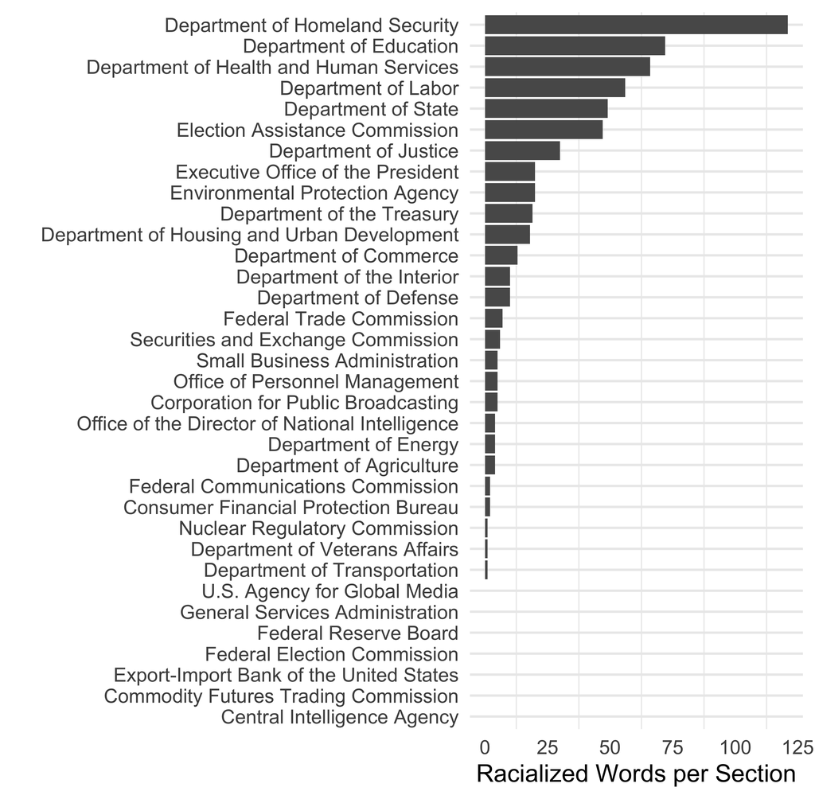

Figure 11: Distribution of Racialized Words in Mandate For Leadership (Project 2025)

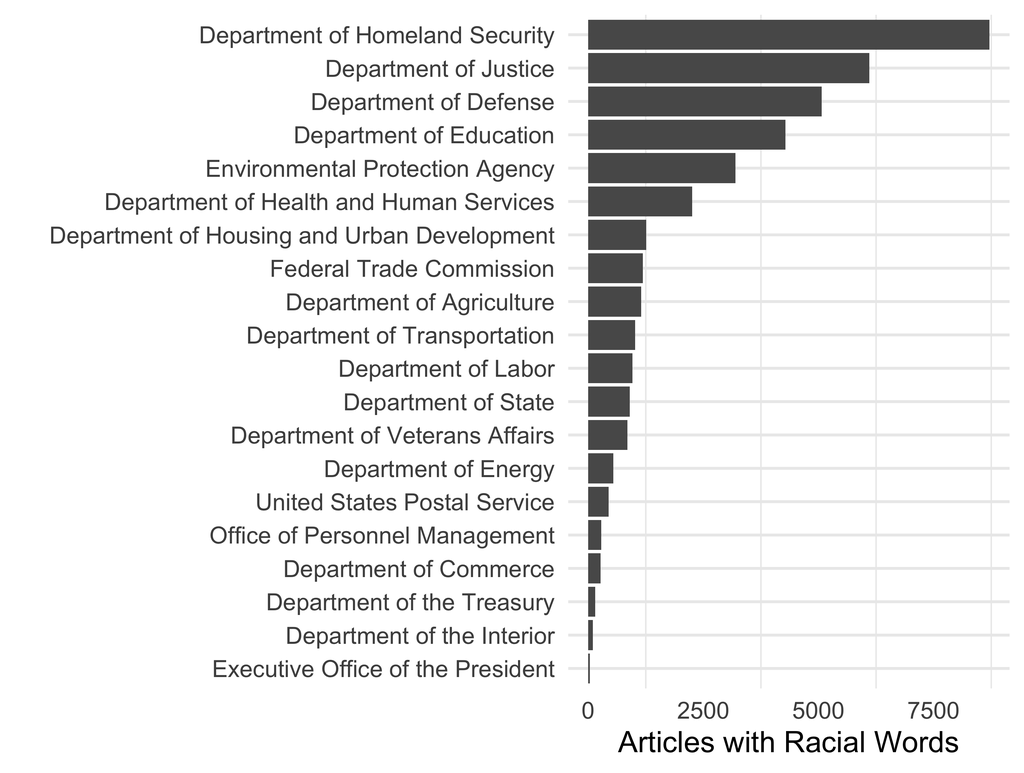

Figure 12: Distribution of Racialized Words in New York Times Articles, 2005-2025

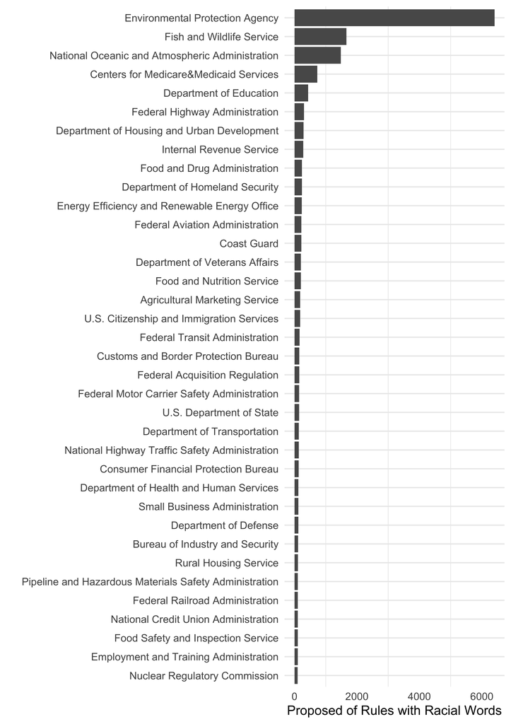

Figure 13: Distribution of Racialized Words in Proposed and Final Rules, 2005-2025

## Racialization & DOGE Layoffs

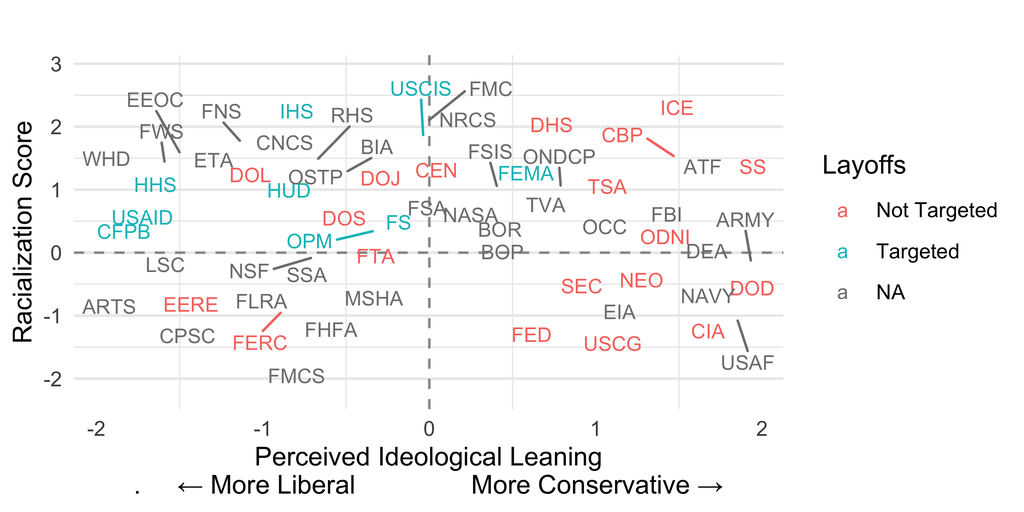

## Project 2025 & DOGE Layoffs

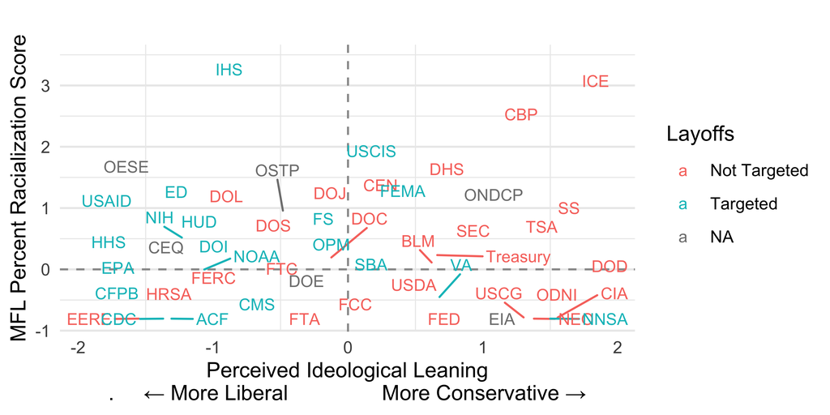

## NYT & DOGE Layoffs

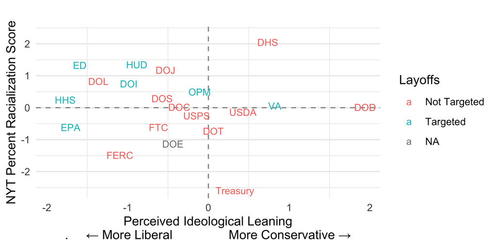

## Rulemaking Racialization & Layoffs

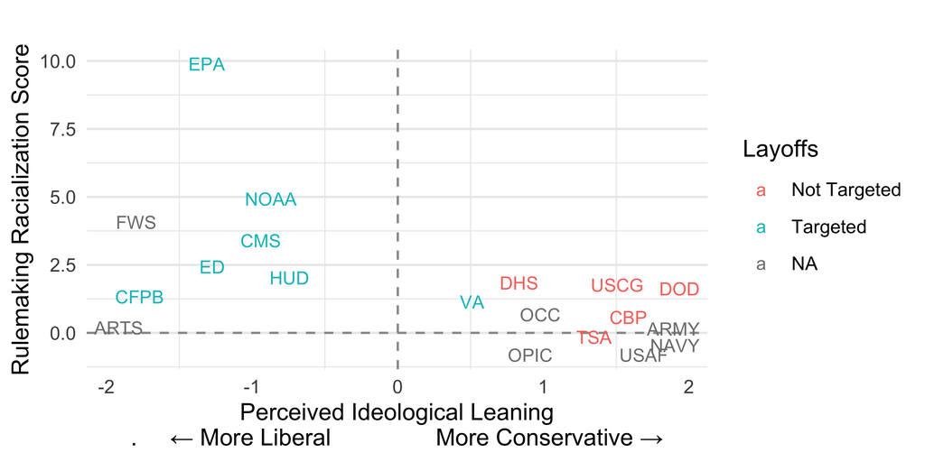

## Layoff Predictions

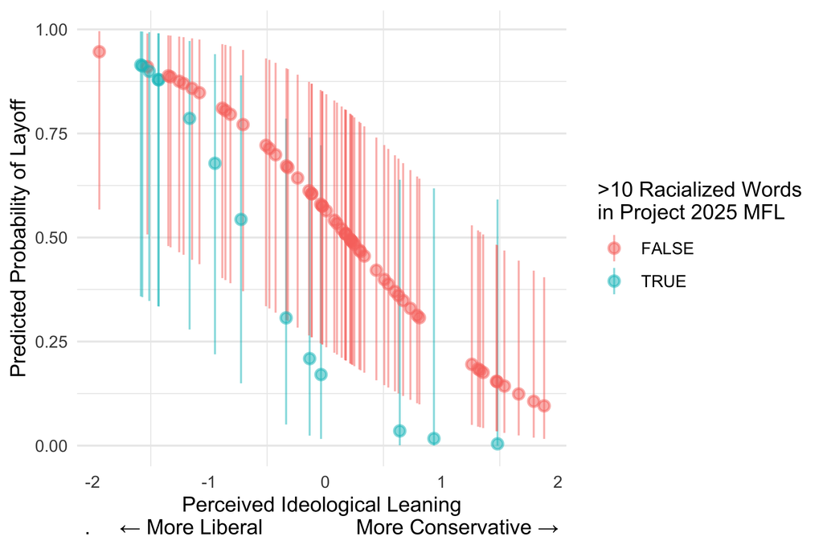